# presentation slides

[figure not shown]

### SLAMming with Spheros

Srinivas Kandasamy

Advisor: Dr. Tamás Keviczky

Delft Center for Systems and Control

## Outline

- Introduction

## Introduction

"SLAM asks for a mobile robot, placed at an unknown location in an unknown environment, to build a consistent map of the environment while simultaneously determine its location within this map."

### Illustration of SLAM

[figure not shown]

### Measurement Step

[figure not shown]

### Update Step

[figure not shown]

### Prediction Step

[figure not shown]

### Measurement Step

[figure not shown]

### Update Step

[figure not shown]

### Prediction Step

[figure not shown]

### Measurement Step

[figure not shown]

### Update Step

[figure not shown]

### An impact-based approach to Simultaneous Localization and Mapping

[figure not shown]

## Outline

- Introduction
- Approaches

## Approaches to solve SLAM

- Online Estimation
- Offline optimization

## Bayesian model of SLAM

[figure not shown]

## Factored version of SLAM

[figure not shown]

### Online Estimation problem

- Exploits exact conditional independence of SLAM
- Factored Solution
  - Robot localization problem
  - Collection of landmark estimation problems
- Incorporates nonlinearities in the probability distribution of robot location and map features

### Offline Optimization problem

- Joint estimation of robot location and map features
- Maintains the full set of correlations through covariance or information matrix
- Gaussian distribution over robot location and map features

### A sample non-Gaussian distribution

[figure not shown]

## Outline

- Introduction
- Approaches
- Promising one

## FastSLAM

- Probability distribution as random samples
- Path estimation using particle filter
- Landmark location estimation using low-dimensional EKFs

$$ P(X_{0:k},m|Z_{0:k},U_{0:k})\sim\left\lbrace w_k^{(i)}\,,\,X^{(i)}_{0:k}\,,\,\prod_j^{M}P(m_j|X^{(i)}_{0:k},Z_{0:k})\right\rbrace_i^N $$

[figure not shown]

## Outline

- Introduction
- Approaches
- Promising one
- Environment representation

### Environment representation

- Point landmarks
  - Every collision is a landmark
  - Kalman filter for every collision
  - Problem in data association - Difficulty in correction of landmarks on multiple sightings
- Occupancy grid map
  - Map as an occupany grid
  - Huge bookkeeping

### Point landmarks for SLAM

```python
# Python code for SLAM with point landmarks
%run ../../New_world/ball_in_a_room.ipynb
```

### Resulting map of the environment

[figure not shown]

### Shortcomings with point landmarks

- Not a single landmark update
- Updated step to be modified
  - Selective update of covariance matrix in respective orthogonal space
  - Brittle method
- Gaussian mixture models
  - Difficulty in pruning data
- Need a better way to initialize a feature

### Feature Initialization

- Strike a mid-level between the two
- Wall regarded as a landmark
- Each face of the wall as a feature of landmark
- Rasterize the landmark into a resulting histogram
- Use discrete Bayes filter to build the map

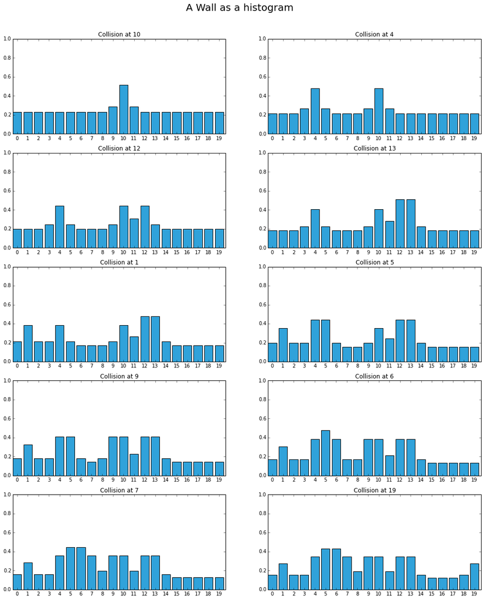

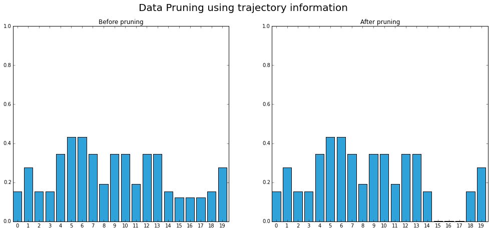

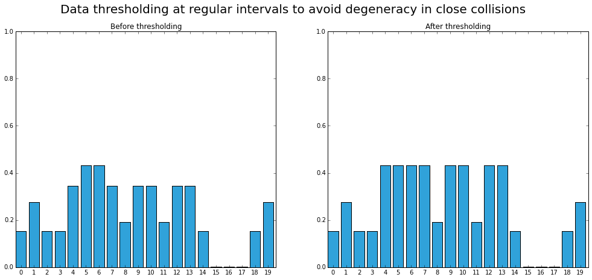

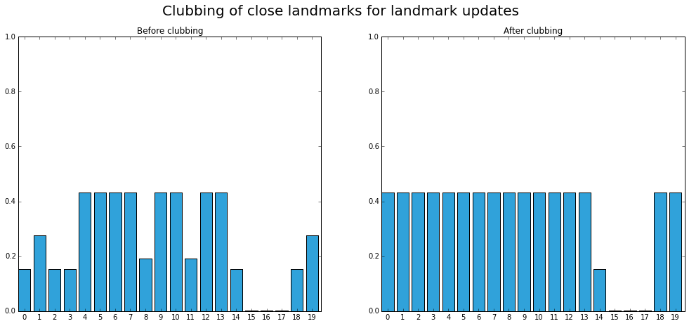

```
Final look of the wall in map
```

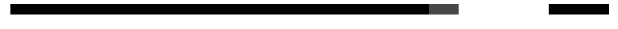

```python
# Python code for histogram filter
%run ../../New_world/histogram_filter_wall_hypothesis.ipynb
```

## Outline

- Introduction
- Approaches
- Promising one
- Environment representation
- Data Association

## Data Association

- Association of new measurement to existing map
- Nearest Neighbour approach
- Robust to feature correspondences
- Decision made on a per-particle basis

## Conclusion

1. FastSLAM algorithm suitable for impact-based SLAM
2. Point landmarks are less suitable here
3. Histogram filter preferred for map representation
4. Nearest Neighbour approach is robust for data association in FastSLAM

## Next workshop .....

- Incorporating histogram filter into the FastSLAM algorithm
- Modify offline version of FastSLAM algorithm to accomodate these new changes
- Online version of FastSLAM
- Practical results